# Utegulov_Plant_Seedling

## Plant Seedlings Classification

**Author**: Aidos Utegulov  
**Cohort**: Feb 21

```python
# Import necessary libraries

import numpy as np                               # Import numpy
from skimage import data, io                     # Import skimage library (data - Test images and example data.
                                                 #                          io - Reading, saving, and displaying images.)
import matplotlib.pyplot as plt                  # Import matplotlib.pyplot (Plotting framework in Python.)

import os                                        # This module provides a portable way of using operating system dependent functionality.
os.environ['TF_CPP_MIN_LOG_LEVEL'] = '3'
import warnings
# Suppress warnings
warnings.filterwarnings('ignore')

#from google.colab.patches import cv2_imshow      # To show images using cv2 module
import seaborn as sns
import matplotlib.pyplot as plt
%matplotlib inline
from sklearn.model_selection import train_test_split

from tensorflow.keras.models import Sequential, Model
from tensorflow.keras.layers import Dense, Dropout, Flatten #importing different layers
from tensorflow.keras.layers import Conv2D, MaxPooling2D, BatchNormalization, Activation, Input, LeakyReLU,Activation
from tensorflow.keras import backend as K
from keras.callbacks import EarlyStopping
from sklearn.metrics import accuracy_score, confusion_matrix
from tensorflow.keras.optimizers import Adam
from tensorflow.keras import losses, optimizers
from keras.callbacks import ModelCheckpoint
```

## **Load images and labels**

```python
# Mount Google drive so dataset can be accessed (The dataset file (monkeys_dataset.zip) is inside google drive.)
#from google.colab import drive
#drive.mount('/content/drive')
```

```python
# Set the path to the dataset folder. (The dataset contains three image folders: "predict", "test", and "train")
images = np.load("images.npy")
```

```python
images.shape
```

```
(4750, 128, 128, 3)
```

```python
import pandas as pd;
labels = pd.read_csv("Labels.csv");
```

```python
labels.shape
```

```
(4750, 1)
```

# **Dataset summary**

```python
labels.head()
```

|  | Label |
| --- | --- |
| 0 | Small-flowered Cranesbill |
| 1 | Small-flowered Cranesbill |
| 2 | Small-flowered Cranesbill |
| 3 | Small-flowered Cranesbill |
| 4 | Small-flowered Cranesbill |

```python
def perc_on_bar(feature):
    """
    plot
    feature: categorical feature
    the function won't work if a column is passed in the hue parameter
    """
    # Creating a countplot for the feature
    sns.set(rc={"figure.figsize": (25, 5)})
    ax = sns.countplot(x=feature, data=labels)

    total = len(feature)  # length of the column
    for p in ax.patches:
        percentage = "{:.1f}%".format(
            100 * p.get_height() / total
        )  # percentage of each class of the category
        x = p.get_x() + p.get_width() / 2 - 0.1  # width of the plot
        y = p.get_y() + p.get_height()  # hieght of the plot
        ax.annotate(percentage, (x, y), size=14)  # annotate the percantage

    plt.show()  # show the plot
```

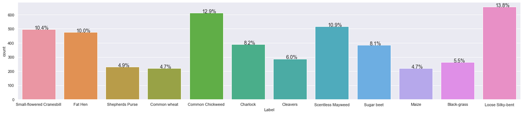

```python
perc_on_bar(labels['Label'])
```

```python
labels.nunique()
```

```
Label    12
dtype: int64
```

```python
images[1].shape
```

```
(128, 128, 3)
```

## Display images

- find all unique classes and then find the index of the first occurence of each class, save as a tuple containing the unique label and it's index of first occurence
- then plot the images using the array of tuples found in previous step

```python
unique_classes = labels['Label'].unique()
indexes_found = []
for val in unique_classes:
  idx = labels['Label'].eq(val).idxmax()
  pair = (val, idx)
  indexes_found.append(pair)
indexes_found
```

```
[('Small-flowered Cranesbill', 0),
 ('Fat Hen', 496),
 ('Shepherds Purse', 971),
 ('Common wheat', 1202),
 ('Common Chickweed', 1423),
 ('Charlock', 2034),
 ('Cleavers', 2424),
 ('Scentless Mayweed', 2711),
 ('Sugar beet', 3227),
 ('Maize', 3612),
 ('Black-grass', 3833),
 ('Loose Silky-bent', 4096)]
```

[figure not shown]

```python
def display_images(img_source):
  fig = plt.figure(figsize=(16, 8))
  fig.set_size_inches(16, 16)
  for i in range(0, len(indexes_found)):
    ax = plt.subplot(4, 4, i + 1)
    ax.axis('Off')
    plt.title(indexes_found[i][0])
    plt.imshow(img_source[indexes_found[i][1]])
  plt.show()

display_images(images)
```

**Observations**

- The dataset contains 4750 RGB images of size 128x128 pixels
- There are 4750 labels of 12 unique categories

# **Data Preprocessing**

## Normalize images

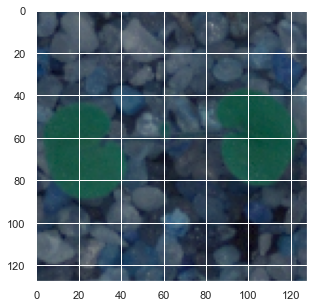

```python
normalized_images = images/255.0
plt.imshow(normalized_images[0])
```

## Apply Gaussian Blur

```python
from skimage.filters import gaussian
blurred_images = [];
for img in normalized_images:
  blurred_images.append(gaussian(img, sigma=1))
blurred = np.array(blurred_images)
blurred.shape
```

```
(4750, 128, 128, 3)
```

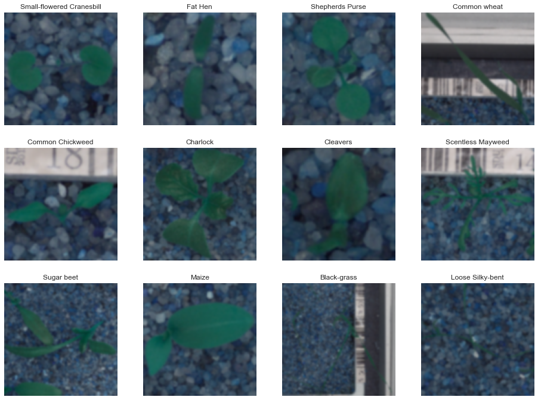

```python
display_images(blurred)
```

**Observations**

- As you can see, we successfully blurred the images
- We could have also defined a two-dimensional gaussian filter and convolved it over each channel and then stacked them up, but there is a library to do all that

# **Encode labels and split the dataset**

## Encode labels

```python
dummies = pd.get_dummies(labels)
dummies.head()
```

|  | Label_Black-grass | Label_Charlock | Label_Cleavers | Label_Common Chickweed | Label_Common wheat | Label_Fat Hen | Label_Loose Silky-bent | Label_Maize | Label_Scentless Mayweed | Label_Shepherds Purse | Label_Small-flowered Cranesbill | Label_Sugar beet |
| --- | --- | --- | --- | --- | --- | --- | --- | --- | --- | --- | --- | --- |
| 0 | 0 | 0 | 0 | 0 | 0 | 0 | 0 | 0 | 0 | 0 | 1 | 0 |
| 1 | 0 | 0 | 0 | 0 | 0 | 0 | 0 | 0 | 0 | 0 | 1 | 0 |
| 2 | 0 | 0 | 0 | 0 | 0 | 0 | 0 | 0 | 0 | 0 | 1 | 0 |
| 3 | 0 | 0 | 0 | 0 | 0 | 0 | 0 | 0 | 0 | 0 | 1 | 0 |
| 4 | 0 | 0 | 0 | 0 | 0 | 0 | 0 | 0 | 0 | 0 | 1 | 0 |

```python
y = dummies.to_numpy()
print("Shape of y:", y.shape)
print("One value of y:", y[0])
```

```
Shape of y: (4750, 12)
One value of y: [0 0 0 0 0 0 0 0 0 0 1 0]
```

## Split the dataset

```python
X_train, X_test, y_train, y_test = train_test_split(blurred, y, test_size=0.3, random_state=1)

X_train, X_val, y_train, y_val = train_test_split(X_train, y_train, test_size=0.5, random_state=1)
```

```python
print("X_train shape:", X_train.shape)
print("y_train shape:", y_train.shape)

print("X_val shape:", X_val.shape)
print("y_val shape:", y_val.shape)

print("X_test shape:", X_test.shape)
print("y_test shape:", y_test.shape)
```

```
X_train shape: (1662, 128, 128, 3)
y_train shape: (1662, 12)
X_val shape: (1663, 128, 128, 3)
y_val shape: (1663, 12)
X_test shape: (1425, 128, 128, 3)
y_test shape: (1425, 12)
```

- Data seem to be split according to plan, the shapes are compatible with Keras model requirements

# **Build the model**

```python
cnn_model = Sequential()
cnn_model.add(Conv2D(16, (3,3), activation='relu', input_shape=(128, 128, 3)))
cnn_model.add(MaxPooling2D(2,2))
cnn_model.add(Conv2D(32, (3,3), activation='relu'))
cnn_model.add(MaxPooling2D(2,2))
cnn_model.add(Conv2D(64, (3,3), activation='relu'))
cnn_model.add(MaxPooling2D(2,2))
cnn_model.add(Flatten())
cnn_model.add(Dense(512, activation='relu'))
cnn_model.add(Dense(12, activation='softmax'))

cnn_model.compile(loss="categorical_crossentropy", optimizer="Adam", metrics = ['accuracy'])
```

```python
cnn_model.summary()
```

```
Model: "sequential"
_________________________________________________________________
Layer (type)                 Output Shape              Param #
=================================================================
conv2d (Conv2D)              (None, 126, 126, 16)      448
_________________________________________________________________
max_pooling2d (MaxPooling2D) (None, 63, 63, 16)        0
_________________________________________________________________
conv2d_1 (Conv2D)            (None, 61, 61, 32)        4640
_________________________________________________________________
max_pooling2d_1 (MaxPooling2 (None, 30, 30, 32)        0
_________________________________________________________________
conv2d_2 (Conv2D)            (None, 28, 28, 64)        18496
_________________________________________________________________
max_pooling2d_2 (MaxPooling2 (None, 14, 14, 64)        0
_________________________________________________________________
flatten (Flatten)            (None, 12544)             0
_________________________________________________________________
dense (Dense)                (None, 512)               6423040
_________________________________________________________________
dense_1 (Dense)              (None, 12)                6156
=================================================================
Total params: 6,452,780
Trainable params: 6,452,780
Non-trainable params: 0
_________________________________________________________________
```

```python
stop_early = EarlyStopping(monitor='val_loss', patience=5)
```

```python
model_history = cnn_model.fit(X_train, y_train, verbose=1, batch_size=256,
                                  validation_data=(X_val, y_val),
                                  callbacks=[stop_early],
                                  epochs=10)
```

**Observations**

- Training accuracy was pretty horrible - 59%, validation accuracy was even lower - only 53%

# Evaluating the model

```python
cnn_model.evaluate(X_test,y_test)
```

```
[1.4001824855804443, 0.5178947448730469]
```

```
dict_keys(['loss', 'accuracy', 'val_loss', 'val_accuracy'])
```

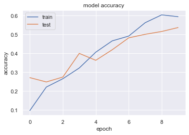

```python
print(model_history.history.keys())
# summarize history for accuracy
plt.plot(model_history.history['accuracy'])
plt.plot(model_history.history['val_accuracy'])
plt.title('model accuracy')
plt.ylabel('accuracy')
plt.xlabel('epoch')
plt.legend(['train', 'test'], loc='upper left')
plt.show()
```

## Confusion Matrix

```python
y_test_pred_1 = cnn_model.predict(X_test)
y_test_pred_classes_1 = np.argmax(y_test_pred_1, axis=1)
y_test_pred_prob_1 = np.max(y_test_pred_1, axis=1)
test_labels = np.argmax(y_test, axis=1)
```

```python
accuracy_score(test_labels, y_test_pred_classes_1)
```

```
0.5178947368421053
```

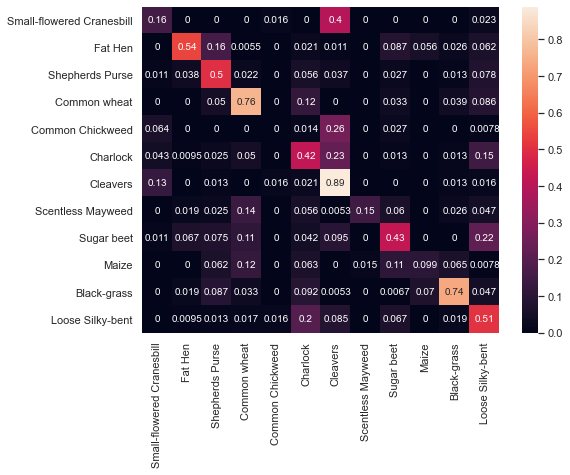

```python
cf_matrix = confusion_matrix(test_labels, y_test_pred_classes_1)

# Confusion matrix normalized per category true value
cf_matrix_n1 = cf_matrix/np.sum(cf_matrix, axis=1)
plt.figure(figsize=(8,6))
sns.heatmap(cf_matrix_n1, xticklabels=unique_classes, yticklabels=unique_classes, annot=True)
```

```python
from sklearn.metrics import precision_recall_fscore_support

p=precision_recall_fscore_support(test_labels, y_test_pred_classes_1, average=None,labels=list(np.unique(test_labels)))

print(" Precision is {}\n Recall is {} \n f_beta Score is {}".format(p[0],p[1],p[2]))
```

```
 Precision is [0.38461538 0.77027027 0.49382716 0.60526316 0.         0.38216561
 0.44094488 0.90909091 0.5        0.4375     0.7755102  0.40625   ]
 Recall is [0.15957447 0.54285714 0.5        0.76243094 0.         0.42253521
 0.88888889 0.14925373 0.42666667 0.09859155 0.73548387 0.5078125 ]
 f_beta Score is [0.22556391 0.63687151 0.49689441 0.67481663 0.         0.40133779
 0.58947368 0.25641026 0.46043165 0.16091954 0.75496689 0.45138889]
```

**Observations**

- Some of the images weren't even identified, I have 0's in all of the metrics. Scentless Mayweed had the highest precision (90%), Cleavers had highest recall (88%) and Black Grass had pretty good overall scores with highest f1_score (75%), decent recall (73%) and also decent accuracy (77%). Others did not do well
- Perhaps if we change our model architecture, we could see better results

## Another model with different architecture

**Note:** This model was provided to us during mentoring session. The difference here is that this model has one more Convolution layer, also there are added Dropout layers after each convolution and pooling.

```python
es = EarlyStopping(monitor='val_loss', mode='min', verbose=1, patience=20)
mc = ModelCheckpoint('best_model.h5', monitor='val_accuracy', mode='max', verbose=1, save_best_only=True)
model = Sequential()

model.add(Conv2D(filters = 16, kernel_size = (5,5),padding = 'Same',
                 activation ='relu', input_shape = (128,128,3)))
model.add(MaxPooling2D(pool_size=(2,2)))
model.add(Dropout(0.25))
#
model.add(Conv2D(filters = 32, kernel_size = (3,3),padding = 'Same',
                 activation ='relu'))
model.add(MaxPooling2D(pool_size=(2,2), strides=(2,2)))
model.add(Dropout(0.25))
#
model.add(Conv2D(filters = 64, kernel_size = (3,3),padding = 'Same',
                 activation ='relu'))
model.add(MaxPooling2D(pool_size=(2,2), strides=(2,2)))
model.add(Dropout(0.3))
#
model.add(Conv2D(filters = 128, kernel_size = (2,2),padding = 'Same',
                 activation ='relu'))
model.add(MaxPooling2D(pool_size=(2,2), strides=(2,2)))
model.add(Dropout(0.3))

#
model.add(Flatten())
model.add(Dense(1024, activation = "relu"))
model.add(Dropout(0.5))
model.add(Dense(12, activation = "softmax"))
optimizer = Adam(lr=0.001, beta_1=0.9, beta_2=0.999)
model.compile(optimizer = optimizer , loss = "categorical_crossentropy", metrics=["accuracy"])
epochs = 200
batch_size = 64



es = EarlyStopping(monitor='val_loss', mode='min', verbose=1, patience=5)
mc = ModelCheckpoint('best_model.h5', monitor='val_accuracy', mode='max', verbose=1, save_best_only=True)

history=model.fit(X_train,
          y_train,  #It expects integers because of the sparse_categorical_crossentropy loss function
          epochs=50,#number of iterations over the entire dataset to train on
          batch_size=128,callbacks=[es, mc],use_multiprocessing=True, validation_data=(X_val, y_val), verbose = 1)#number of samples per gradient update for training
```

```
Epoch 00001: val_accuracy improved from -inf to 0.13830, saving model to best_model.h5

Epoch 00002: val_accuracy did not improve from 0.13830

Epoch 00003: val_accuracy improved from 0.13830 to 0.16957, saving model to best_model.h5

Epoch 00004: val_accuracy improved from 0.16957 to 0.22429, saving model to best_model.h5

Epoch 00005: val_accuracy improved from 0.22429 to 0.28142, saving model to best_model.h5

Epoch 00006: val_accuracy improved from 0.28142 to 0.36079, saving model to best_model.h5

Epoch 00007: val_accuracy improved from 0.36079 to 0.39387, saving model to best_model.h5

Epoch 00008: val_accuracy improved from 0.39387 to 0.44257, saving model to best_model.h5

Epoch 00009: val_accuracy improved from 0.44257 to 0.47384, saving model to best_model.h5

Epoch 00010: val_accuracy improved from 0.47384 to 0.51594, saving model to best_model.h5

Epoch 00011: val_accuracy did not improve from 0.51594

Epoch 00012: val_accuracy improved from 0.51594 to 0.52375, saving model to best_model.h5

Epoch 00013: val_accuracy did not improve from 0.52375

Epoch 00014: val_accuracy improved from 0.52375 to 0.52856, saving model to best_model.h5

Epoch 00015: val_accuracy did not improve from 0.52856

Epoch 00016: val_accuracy did not improve from 0.52856

Epoch 00017: val_accuracy improved from 0.52856 to 0.53157, saving model to best_model.h5

Epoch 00018: val_accuracy did not improve from 0.53157

Epoch 00019: val_accuracy improved from 0.53157 to 0.57066, saving model to best_model.h5

Epoch 00020: val_accuracy did not improve from 0.57066

```

[output cut: 17 more lines]

```

Epoch 00030: val_accuracy did not improve from 0.67949

Epoch 00031: val_accuracy improved from 0.67949 to 0.71197, saving model to best_model.h5

Epoch 00032: val_accuracy did not improve from 0.71197

Epoch 00033: val_accuracy did not improve from 0.71197

Epoch 00034: val_accuracy did not improve from 0.71197

Epoch 00035: val_accuracy did not improve from 0.71197

Epoch 00036: val_accuracy did not improve from 0.71197
Epoch 00036: early stopping
```

## Model evaluation

```python
model.evaluate(X_test,y_test)
```

```
[1.2184512615203857, 0.6498245596885681]
```

**Observations**

- training came to an early stop, reached validation accuracy of 71%, training accuracy also reached 89%
- the model did better than the previous one on the testing set - 64% accuracy

```python
y_test_pred_2 = model.predict(X_test)
y_test_pred_classes_2 = np.argmax(y_test_pred_2, axis=1)
y_test_pred_prob_2 = np.max(y_test_pred_2, axis=1)
```

```python
accuracy_score(test_labels, y_test_pred_classes_2)
```

```
0.6498245614035087
```

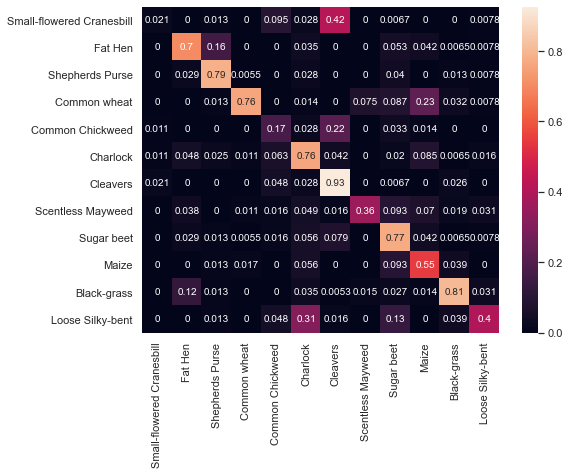

```python
cf_matrix2 = confusion_matrix(test_labels, y_test_pred_classes_2)

# Confusion matrix normalized per category true value
cf_matrix_n2 = cf_matrix2/np.sum(cf_matrix2, axis=1)
plt.figure(figsize=(8,6))
sns.heatmap(cf_matrix_n2, xticklabels=unique_classes, yticklabels=unique_classes, annot=True)
```

```python
p2=precision_recall_fscore_support(test_labels, y_test_pred_classes_2, average=None,labels=list(np.unique(test_labels)))

print(" Precision is {}\n Recall is {} \n f_beta Score is {}".format(p2[0],p2[1],p2[2]))
```

```
 Precision is [0.33333333 0.7254902  0.75       0.93877551 0.37931034 0.5320197
 0.53846154 0.8        0.56585366 0.52702703 0.81168831 0.77272727]
 Recall is [0.0212766  0.7047619  0.7875     0.76243094 0.17460317 0.76056338
 0.92592593 0.35820896 0.77333333 0.54929577 0.80645161 0.3984375 ]
 f_beta Score is [0.04       0.71497585 0.76829268 0.84146341 0.23913043 0.62608696
 0.68093385 0.49484536 0.65352113 0.53793103 0.80906149 0.5257732 ]
```

**Observations**

# Visualizing predicted data

```python
x_data = [X_test[2], X_test[3], X_test[33], X_test[36], X_test[59]]
```

```python
y_data = [test_labels[2], test_labels[3], test_labels[33], test_labels[36], test_labels[59]]
```

```python
y_pred = [y_test_pred_classes_2[2], y_test_pred_classes_2[3], y_test_pred_classes_2[33], y_test_pred_classes_2[36], y_test_pred_classes_2[59]]
```

```python
print("Predicted data:", y_pred)
print("Actual data:", y_data)
```

```
Predicted data: [8, 3, 6, 2, 9]
Actual data: [8, 3, 0, 2, 9]
```

```
Showing predicted data
```

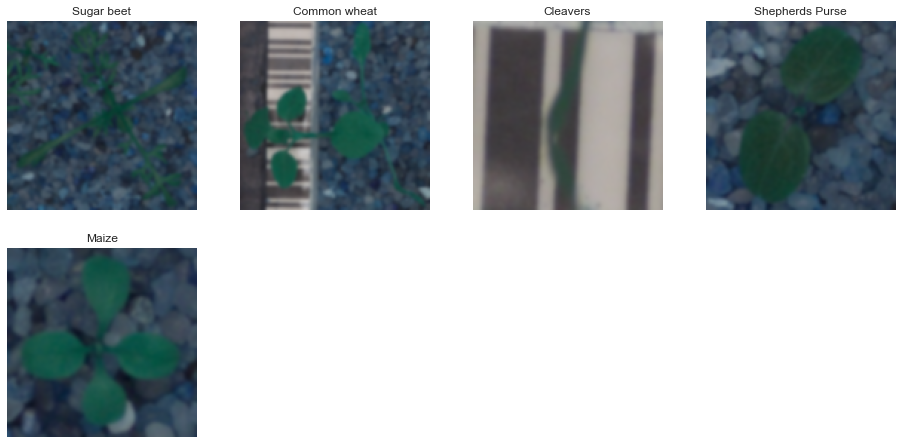

```python
def show_test_img(labels):
    fig = plt.figure(figsize=(20, 8))
    fig.set_size_inches(16, 16)
    for i in range(0, len(y_pred)):
        ax = plt.subplot(4, 4, i + 1)
        ax.axis('Off')
        plt.title(unique_classes[labels[i]])
        plt.imshow(x_data[i])
    plt.show()

print("Showing predicted data")
show_test_img(y_pred)
```

```
Showing actual data
```

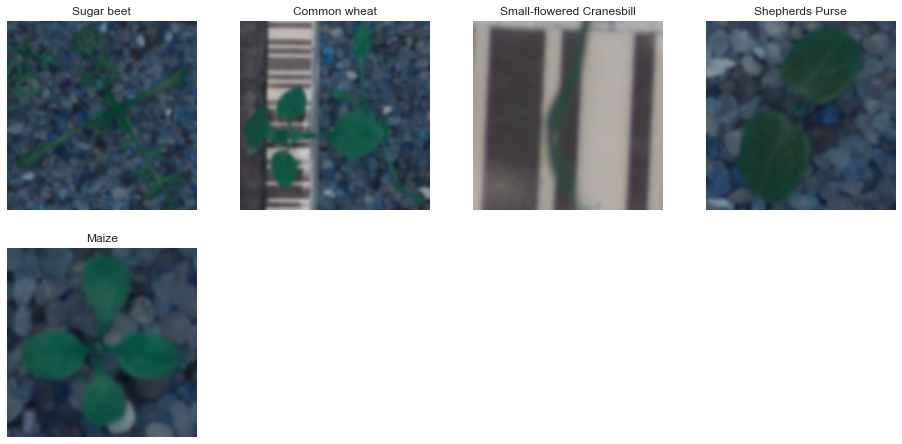

```python
print("Showing actual data")
show_test_img(y_data)
```

**Observations**

- I don't really know how to visualize this data, but we can see that the model correctly predicts 4 out of 5 images, which, to me, is impressive
- My model confused Cleavers with small-flowered cranesbill, which may be due to blurring, or some other noise

# Conclusion